# CV_Jairo Sebastián Quiroga

Jairo

2024-04-02

## Curriculum Vitae

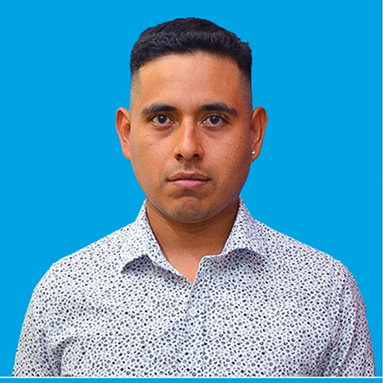

FotoPerfil - Jairo Sebastián Quiroga

### 1. Contacto

- cel: *3873 401123*
- mail: jairosq91@gmail.com

### 2. Datos Personales

- edad: 33 años
- DNI: 35.780.800
- domicilio: ciudad de Tartagal

### 3. Formacion

> Educación universitaria: *Titulo Técnico Universitario en Perforaciones*. Sede Regional Tartagal - Facultad de Ciencias Naturales - Universidad Nacional de Salta. Resolución ministerial n° 1109/02. Registro n° 13979. Tartagal 28 de agosto de 2017.

> Educación secundaria: *Titulo Polimodal en Ciencias Naturales*. Colegio secundario n° 5077 Dr. Jesús Miguel Reyes. Resolución ministerial n° 4118/00. Libro matriz n° 3 - Folio n° 134 – Registro n° 236841. Tartagal 26 agosto de 2009.

#### Estudios en curso

* *Diplomatura Universitaria en Gestión y Tecnologías para el desarrollo Convencional y No Convencional de Hidrocarburos*. Universidad Nacional de la Patagonia Austral & Fundacion YPF.

* *Cursos Inglés nivel intermedio*. Universidad Provincial de Administración, Tecnología y Oficios

#### Talleres de Actualizacion

* *El desafío SIG desde CERO, Biodiversidad y Medio Ambiente*. 30 horas cátedras sincrónicas. INSTITUTO AMBIENTAL GIS. República de Colombia 24 de marzo 2023.

* *Testing Manual, Ágil y con Herramientas* del trayecto formativo Programación / Testing de la Universidad Tecnológica Nacional en el marco de Argentina Programa 4.0. 21 de abril del 2023.

* *Testing avanzado* del trayecto formativo Testing de la Universidad Tecnológica Nacional en el marco de Argentina Programa 4.0. 29 de noviembre del 2023.

### 4. Experiencia Laboral

> **diciembre 2023 - Actualidad**. Secretaría del Agua y Recursos Hídricos - Director de Planificaciones.

### 5. Asesorias

> **Consultoría externa sobre aprovechamiento del agua subterránea en los sistemas acuíferos Tartagal – Itiyuro para consumo humano**. *Proyección de la inversión pública al corto plazo en el departamento San Martin*. Realizada en el Concejo Deliberante de la ciudad de Tartagal. 2 de diciembre 2022 – 5 de diciembre 2022.

> **Consultoría externa sobre aprovechamiento y captación de aguas subterráneas para consumo humano**. Realizada en el Concejo Deliberante de la ciudad de General Enrique Mosconi. 12 de diciembre 2022.